# Predicting Train Delays

Yifei Sun & Kathleen Scopis

2022-12-16

# Introduction

### What’s all this for?

The New York Metropolitan area has a problem.

New Jersey Transit (NJT), the third largest public transportation system in the United States, operates a fleet of ~1,200 active trains every day, accounting for early 300 million rides annually across more than 5,000 square miles serviced area. Featuring rail stations across three states, commuters from across the Northeast rely on the transit network to get to work, school, and other daily activities safely, quickly, and reliably.

Despite the important role the NJT plays in the lives of its commuters, there is currently no publicly-available system to accurately predict potential train delays in any of the station lines. This presents a big problem for commuters, as delayed trains drastically affect one’s ability to perform daily tasks and arrive to scheduled meetings on time. Having an accessing which trains are likely to be late puts the power back in the hands of the commuters, who are often left behind in the event of train malfunction. This report aims to suggest one solution to this issue.

This study primarily focuses on the month of January for predicting potential delays across each line serviced by New Jersey Transit.

To view a presentation given regarding this research topic, please visit the following link: https://www.youtube.com/watch?v=X7f8S3BaEYs

# Data and Methodology

The following analysis utilizes linear regression, cross validation, and mean absolute error analyses to predict the number of minutes late a train will be, given its station of origin, time of departure, weather conditions, and a temporal lead variable.

Data is pulled from the following link: https://www.kaggle.com/datasets/pranavbadami/nj-transit-amtrak-nec-performance?select=2018_11.csv The dataset reports on train delay minutes for the entirety of the NJ Transit rail system, as well as selected Amtrak lines, from March 2018 to May 2020.

# Analysis

### Read Data

First, we read in the data found on Kaggle, as well as the shapefile for the state of New Jersey. Once imported, we group aspects of the scheduled time of arrival for each train by its expected arrival hour, day, and week. This will help in later analysis.

```r
dat <- read.csv(file.path("2019_01.csv"))
station <-read.csv(file.path("stops.csv"))
dat<-merge(dat, station, by.x="from", by.y="stop_name")
dat <- dat%>%
  rename(
         from_lat = stop_lat,
         from_lng = stop_lon,
         from_zone_id=zone_id)
dat<-merge(dat, station, by.x="to", by.y="stop_name")
dat <- dat%>%
  rename(
         to_lat = stop_lat,
         to_lng = stop_lon,
         to_zone_id=zone_id)%>%
  dplyr::select(-stop_id.x,-stop_code.x,-stop_id.y,-stop_code.y)
#write.csv(dat, "C:\\Upenn\\d.csv", row.names=FALSE)


#create interval 60

dat <- dat %>%
  mutate(interval60 = floor_date(ymd_hm(scheduled_time), unit = "hour"),
         week = week(interval60),
         dotw = wday(interval60, label=TRUE))

# load census geography

NJCensus <-
  get_acs(geography = "tract",
          variables = c("B01003_001", "B19013_001",
                        "B02001_002", "B08013_001",
                        "B08012_001", "B08301_001",
                        "B08301_010", "B01002_001"),
          year = 2018,
          state = "NJ",
          geometry = TRUE,

          output = "wide")
NJTracts <-
  NJCensus %>%
  as.data.frame() %>%
  distinct(GEOID, .keep_all = TRUE) %>%
  select(GEOID, geometry) %>%
  st_sf
```

```r
dat_census <- st_join(dat %>%
          filter(is.na(from_lng) == FALSE &
                   is.na(from_lat) == FALSE &
                   is.na(to_lat) == FALSE &
                   is.na(to_lng) == FALSE) %>%
          st_as_sf(., coords = c("from_lng", "from_lat"), crs = 4326),
        NJTracts %>%
          st_transform(crs=4326),
        join=st_intersects,
              left = TRUE) %>%
  rename(From.Tract = GEOID) %>%
  mutate(from_lng = unlist(map(geometry, 1)),
         from_lat = unlist(map(geometry, 2)))%>%
  as.data.frame() %>%
  select(-geometry)%>%
  st_as_sf(., coords = c("to_lng", "to_lat"), crs = 4326) %>%
  st_join(., NJTracts %>%
            st_transform(crs=4326),
          join=st_intersects,
          left = TRUE) %>%
  rename(To.Tract = GEOID)  %>%
  mutate(to_lng = unlist(map(geometry, 1)),
         to_lat = unlist(map(geometry, 2)))%>%
  as.data.frame() %>%
  select(-geometry)%>%
  na.omit
```

### Evaluating Weather Patterns

The following graphs highlight an example of the weather conditions later explored in the model: Precipitation, Wind Speed, Temperature, and Visibility.

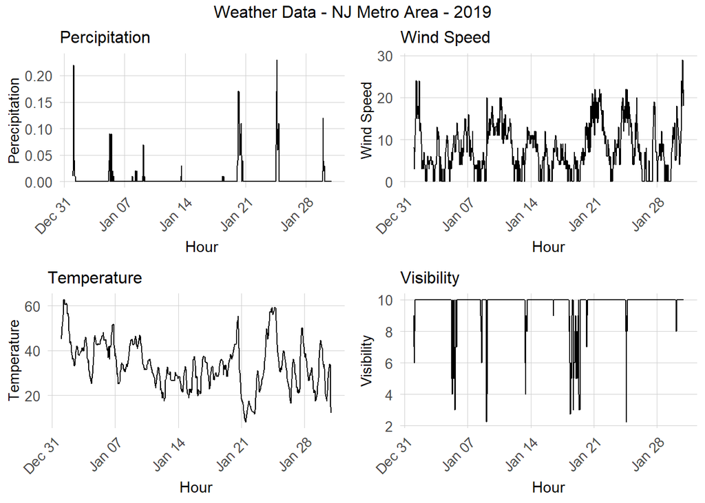

```r
weather.Data <-
  riem_measures(station = "WRI", date_start = "2019-01-01", date_end = "2019-01-31")
weather.Panel  <-
  weather.Data %>%
  dplyr::select(valid, tmpf, p01i, sknt, vsby)%>%
  replace(is.na(.), 0) %>%
    mutate(interval60 = ymd_h(substr(valid,1,13))) %>%
    mutate(week = week(interval60),
           dotw = wday(interval60, label=TRUE)) %>%
    group_by(interval60) %>%
    summarize(Temperature = max(tmpf),
              Precipitation = sum(p01i),
              Wind_Speed = max(sknt),
              Visibility = max(vsby)) %>%
    mutate(Temperature = ifelse(Temperature == 0, 42, Temperature))

#plot
grid.arrange( ncol=2,
  ggplot(weather.Panel, aes(interval60,Precipitation)) + geom_line() +
    labs(title="Percipitation", x="Hour", y="Perecipitation") + plotTheme,
  ggplot(weather.Panel, aes(interval60,Wind_Speed)) + geom_line() +
    labs(title="Wind Speed", x="Hour", y="Wind Speed") + plotTheme,
  ggplot(weather.Panel, aes(interval60,Temperature)) + geom_line() +
    labs(title="Temperature", x="Hour", y="Temperature") + plotTheme,
  ggplot(weather.Panel, aes(interval60,Visibility)) + geom_line() +
    labs(title="Visibility", x="Hour", y="Visibility") + plotTheme,
  top="Weather Data - NJ Metro Area - 2019")
```

### Further Data Cleaning + Lagged Variables

Further data cleaning is needed in order to render the information useful to building out the model.

### Commute Patterns by Time

This graph highlights delay patterns across the month of January, as shown in date of scheduled arrival (shown in hour-intervals) and number of delays per hour. A clear pattern emerges suggesting delays largely happen during peak travel times during the weekday, and are significantly less common during the weekends and off-peak travel hours.

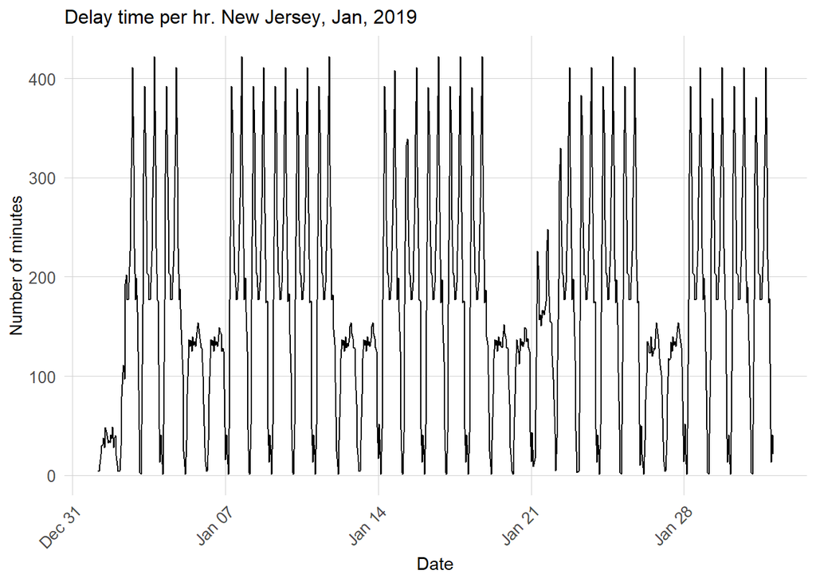

```r
ggplot(dat_census %>%
         group_by(interval60) %>%
         tally())+
  geom_line(aes(x = interval60, y=n))+

  labs(title="Delay time per hr. New Jersey, Jan, 2019",
       x="Date",
       y="Number of minutes")+
  plotTheme
```

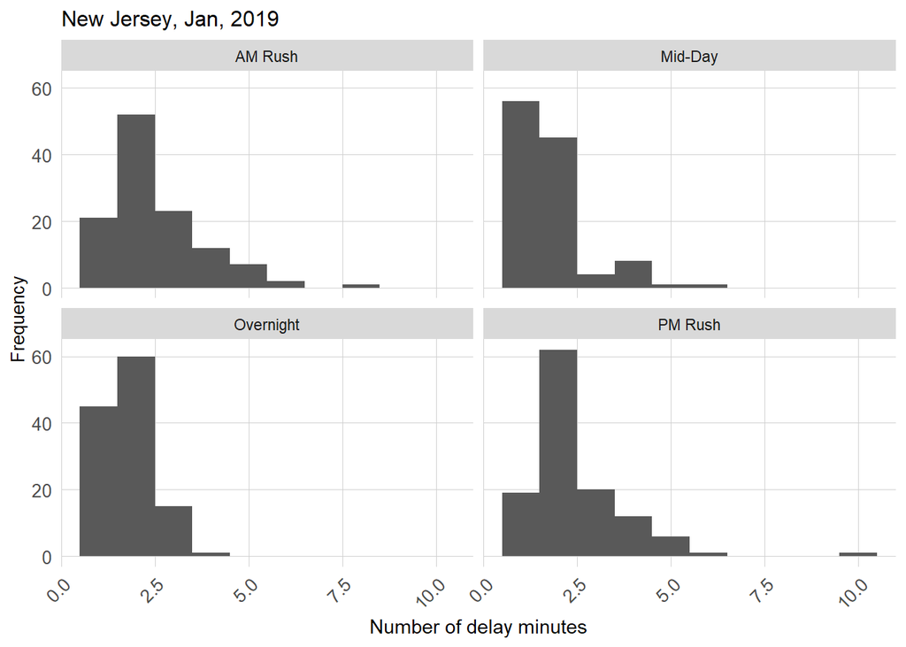

```r
dat_census %>%
        mutate(time_of_day = case_when(hour(interval60) < 7 | hour(interval60) > 18 ~ "Overnight",
                                 hour(interval60) >= 7 & hour(interval60) < 10 ~ "AM Rush",
                                 hour(interval60) >= 10 & hour(interval60) < 15 ~ "Mid-Day",
                                 hour(interval60) >= 15 & hour(interval60) <= 18 ~ "PM Rush"))%>%
         group_by(interval60, from, time_of_day) %>%
         tally()%>%
  group_by(from, time_of_day)%>%
  summarize(mean_delay_minutes = mean(n))%>%
  ggplot()+
  geom_histogram(aes(mean_delay_minutes), binwidth = 1)+
  labs(title="New Jersey, Jan, 2019",
       x="Number of delay minutes",
       y="Frequency")+
  facet_wrap(~time_of_day)+
  plotTheme
```

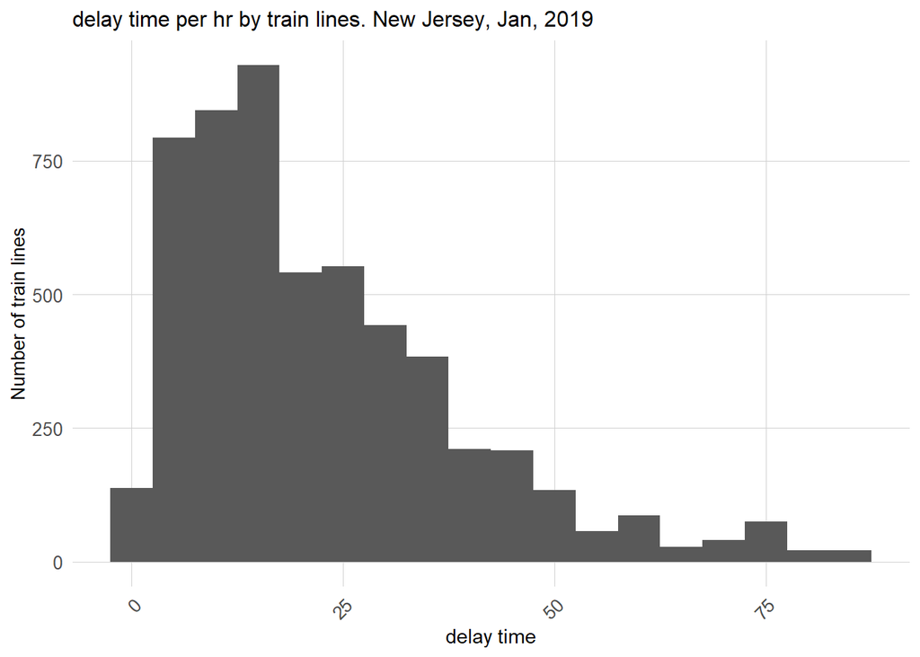

```r
ggplot(dat_census %>%
         group_by(interval60, line) %>%
         tally())+
  geom_histogram(aes(n), binwidth = 5)+
  labs(title="delay time per hr by train lines. New Jersey, Jan, 2019",
       x="delay time",
       y="Number of train lines")+
  plotTheme
```

### Commute Patterns by Day of the Week

The following graphs further illustrate average delay patterns seen throughout the week. Delays are significantly more common during the week, particularly during the peak commute hours of 7AM to 9AM, then again from 5PM to 7PM. This may be due to the increase in rides available during peak hours to accompany increased ride demands, as people crowd onto the platforms to shart their day, then reverse course to return home for the evening.

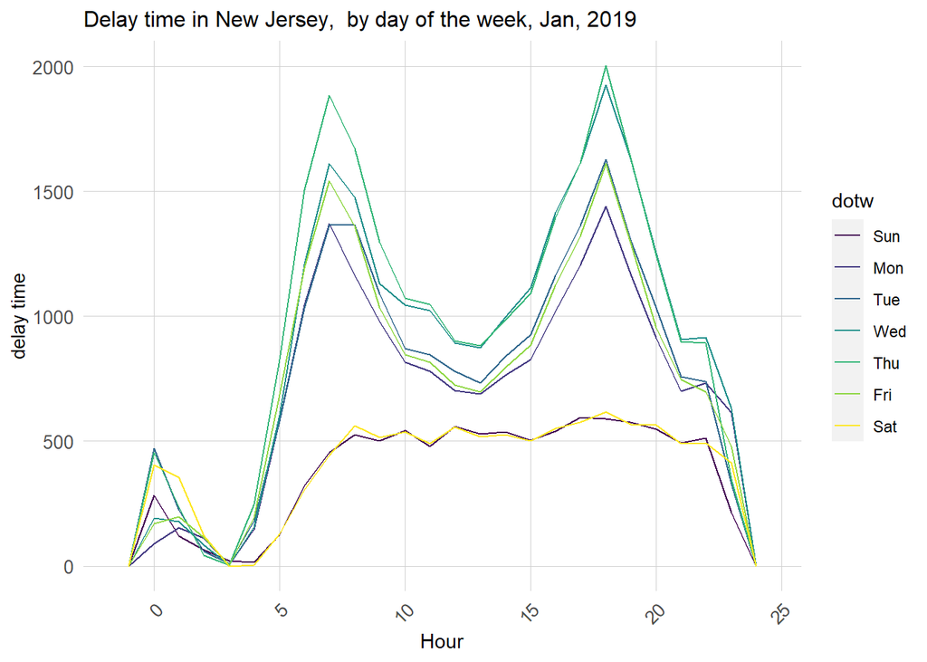

```r
ggplot(dat_census %>% mutate(hour = hour(actual_time)))+
     geom_freqpoly(aes(hour, color = dotw), binwidth = 1)+
  labs(title="Delay time in New Jersey,  by day of the week, Jan, 2019",
       x="Hour",
       y="delay time")+
     plotTheme
```

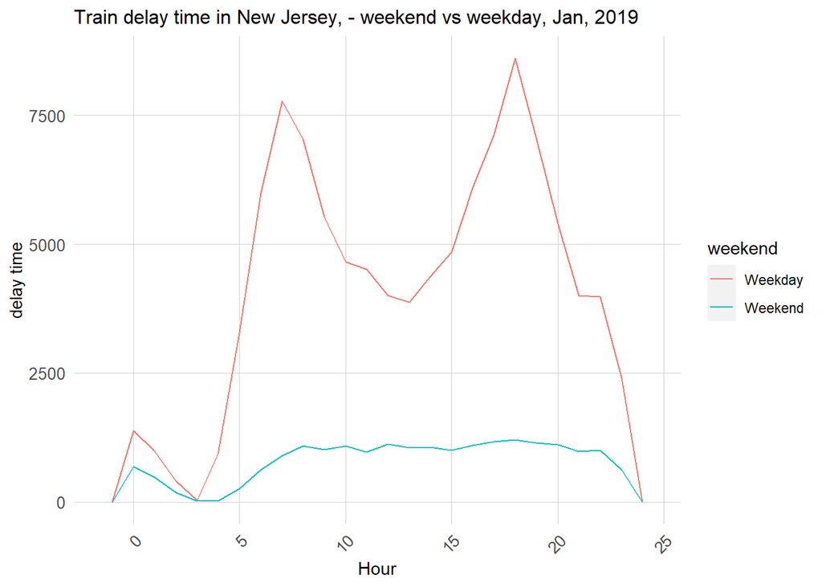

```r
ggplot(dat_census %>%
         mutate(hour = hour(actual_time),
                weekend = ifelse(dotw %in% c("Sat", "Sun"), "Weekend", "Weekday")))+
     geom_freqpoly(aes(hour, color = weekend), binwidth = 1)+
  labs(title="Train delay time in New Jersey, - weekend vs weekday, Jan, 2019",
       x="Hour",
       y="delay time")+
     plotTheme
```

### Spatial Patterns

Analyzing spatial patterns in station delays is a crucial step in understanding underlying causes of delays, as well as potential solutions. If a station is consistently running under delays, that may signify a deeper problem to the management of the station, overcrowding, or not enough service provided.

The following maps suggest that stations to the east and center experience the most delays, particularly during the on-peak times. When combined with the previous graphs, it becomes clear that these stations are simply not recieving enough service during these times, and are likely experiencing a compounding overcrowding problem.

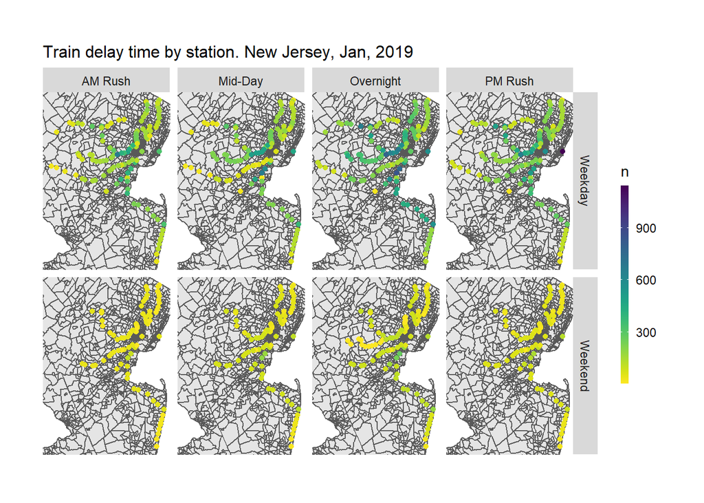

```r
ggplot()+
  geom_sf(data = NJTracts %>%
          st_transform(crs=4326))+
  geom_point(data = dat_census %>%
            mutate(hour = hour(actual_time),
                weekend = ifelse(dotw %in% c("Sat", "Sun"), "Weekend", "Weekday"),
                time_of_day = case_when(hour(interval60) < 7 | hour(interval60) > 18 ~ "Overnight",
                                 hour(interval60) >= 7 & hour(interval60) < 10 ~ "AM Rush",
                                 hour(interval60) >= 10 & hour(interval60) < 15 ~ "Mid-Day",
                                 hour(interval60) >= 15 & hour(interval60) <= 18 ~ "PM Rush"))%>%
              group_by(from, from_lat, from_lng, weekend, time_of_day) %>%
              tally(),
            aes(x=from_lng, y = from_lat, color = n),
            fill = "transparent", alpha = 1, size = 1.5)+
  scale_colour_viridis(direction = -1,
  discrete = FALSE, option = "D")+
  ylim(min(dat_census$from_lat), max(dat_census$from_lat))+
  xlim(min(dat_census$from_lng), max(dat_census$from_lng))+
  facet_grid(weekend ~ time_of_day)+
  labs(title="Train delay time by station. New Jersey, Jan, 2019")+
  mapTheme
```